# Step 3: Transforming Data

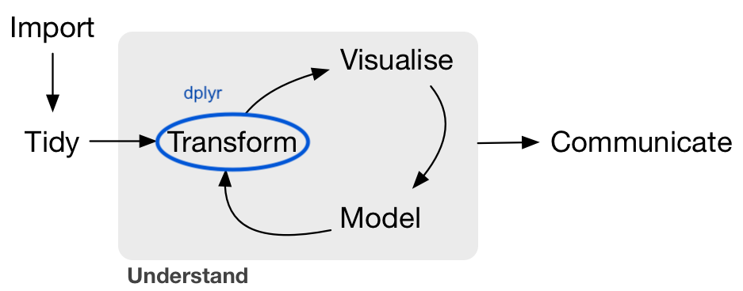

A central principle of tidyverse packages, is the emphasis on minimizing the number of keystrokes and characters needed to attain desired results. In `dplyr`, the use of quotation marks for column names in data frames is often unnecessary. Another noteworthy aspect is that both the input to and output from all functions are in the form of data frames.

`dplyr` package offers a set of key functions, referred to as ‘verbs’, which can be combined to achieve specific and targeted outcomes. Users familiar with functions in Microsoft Excel may recognize similarities in the functionality provided by `dplyr`.

Before we delve into these functions in detail, let’s first explore filtering or *subsetting* data frames using base R functions.

## Subsetting Data Frames

A frequently encountered task in data manipulation is filtering or *subsetting* data to a more focused and potentially relevant subset of values. Data frames (or tibbles) can be subset using base R functions.

```r
library(readr)
# here the first argument is a path
cms_data <- read_csv("data/cms_hospital_patient_satisfaction.csv")
# convert column names to R standard
library(janitor) # remember to install janitor: install.packages("janitor")
cms_data <- cms_data |> clean_names()
```

### Subset by position

Here we use the `[row, col]` syntax to subset data frames.

1. To display a single value:

```r
# display the value in 4th row and 2nd column
cms_data[4, 2]
```

**Output**

| facility_name |
| --- |
| MERCY HOSPITAL FORT SMITH |

```r
# display the 4th row
cms_data[4,]
```

**Output**

| id | facility_name | county | hospital_type | star_rating | no_of_surveys | response_rate | overall_rating |
| --- | --- | --- | --- | --- | --- | --- | --- |
| 040062 | MERCY HOSPITAL FORT SMITH | SEBASTIAN | Acute Care Hospital | 3 | 2506 | 35 | 3 |

3. To display a single column: (Note: columns can be given by name as well) Here, the row value is omitted, thereby retrieving the entire column.

```r
# display the 3rd column
cms_data[, 3] # is same as cms_data[3]
# display the 3rd column (or County column)
cms_data[, "county"] # is same as cms_data["County"]
```

**Output**

| county |
| --- |
| SAN DIEGO |
| COOK |
| LAKE |
| SEBASTIAN |
| SHELBY |
| BRAZOS |
| GREENE |
| MONTEZUMA |
| VIRGINIA BEACH |
| FAYETTE |
| LOS ANGELES |
| MIAMI-DADE |
| SUMNER |
| ISLAND |
| LOS ANGELES |

| county |
| --- |
| SAN DIEGO |
| COOK |
| LAKE |
| SEBASTIAN |
| SHELBY |
| BRAZOS |
| GREENE |
| MONTEZUMA |
| VIRGINIA BEACH |
| FAYETTE |
| LOS ANGELES |
| MIAMI-DADE |
| SUMNER |
| ISLAND |
| LOS ANGELES |

4. To display a range of rows:

```r
# using a vector of indexes
cms_data[c(3, 5, 1), ]
# subsetting
cms_data[2:4,]
```

**Output**

| id | facility_name | county | hospital_type | star_rating | no_of_surveys | response_rate | overall_rating |
| --- | --- | --- | --- | --- | --- | --- | --- |
| 100051 | SOUTH LAKE HOSPITAL | LAKE | Acute Care Hospital | 2 | 1382 | 20 | 2 |
| 440048 | BAPTIST MEMORIAL HOSPITAL | SHELBY | Acute Care Hospital | 2 | 1799 | 18 | 2 |
| 050424 | SCRIPPS GREEN HOSPITAL | SAN DIEGO | Acute Care Hospital | 4 | 3110 | 41 | 5 |

| id | facility_name | county | hospital_type | star_rating | no_of_surveys | response_rate | overall_rating |
| --- | --- | --- | --- | --- | --- | --- | --- |
| 140103 | ST BERNARD HOSPITAL | COOK | Acute Care Hospital | 1 | 264 | 6 | 2 |
| 100051 | SOUTH LAKE HOSPITAL | LAKE | Acute Care Hospital | 2 | 1382 | 20 | 2 |
| 040062 | MERCY HOSPITAL FORT SMITH | SEBASTIAN | Acute Care Hospital | 3 | 2506 | 35 | 3 |

5. To display a range of columns:

```r
# using a vector of indexes
cms_data[, c(1, 3, 6), ]
# subsetting
cms_data[, 4:6]
# using a vector of column names
cms_data[, c("hospital_type", "overall_rating")]
```

**Output**

| id | county | no_of_surveys |
| --- | --- | --- |
| 050424 | SAN DIEGO | 3110 |
| 140103 | COOK | 264 |
| 100051 | LAKE | 1382 |
| 040062 | SEBASTIAN | 2506 |
| 440048 | SHELBY | 1799 |
| 450011 | BRAZOS | 1379 |
| 151317 | GREENE | 114 |
| 061327 | MONTEZUMA | 247 |
| 490057 | VIRGINIA BEACH | 619 |
| 110215 | FAYETTE | 1714 |
| 050704 | LOS ANGELES | 241 |
| 100296 | MIAMI-DADE | 393 |
| 440003 | SUMNER | 680 |
| 501339 | ISLAND | 389 |
| 050116 | LOS ANGELES | 1110 |

| hospital_type | star_rating | no_of_surveys |
| --- | --- | --- |
| Acute Care Hospital | 4 | 3110 |
| Acute Care Hospital | 1 | 264 |
| Acute Care Hospital | 2 | 1382 |
| Acute Care Hospital | 3 | 2506 |
| Acute Care Hospital | 2 | 1799 |
| Acute Care Hospital | 3 | 1379 |
| Critical Access Hospital | 3 | 114 |
| Critical Access Hospital | 4 | 247 |
| Acute Care Hospital | 4 | 619 |
| Acute Care Hospital | 2 | 1714 |
| Acute Care Hospital | 3 | 241 |
| Acute Care Hospital | 4 | 393 |
| Acute Care Hospital | 4 | 680 |
| Critical Access Hospital | 3 | 389 |
| Acute Care Hospital | 3 | 1110 |

| hospital_type | overall_rating |
| --- | --- |
| Acute Care Hospital | 5 |
| Acute Care Hospital | 2 |
| Acute Care Hospital | 2 |
| Acute Care Hospital | 3 |
| Acute Care Hospital | 2 |
| Acute Care Hospital | 3 |
| Critical Access Hospital | 3 |
| Critical Access Hospital | 3 |
| Acute Care Hospital | 3 |
| Acute Care Hospital | 2 |
| Acute Care Hospital | 3 |
| Acute Care Hospital | 3 |
| Acute Care Hospital | 2 |
| Critical Access Hospital | 3 |
| Acute Care Hospital | 2 |

6. To display multiple rows and columns:

```r
cms_data[2:6, c("hospital_type", "no_of_surveys", "response_rate")]
```

**Output**

| hospital_type | no_of_surveys | response_rate |
| --- | --- | --- |
| Acute Care Hospital | 264 | 6 |
| Acute Care Hospital | 1382 | 20 |
| Acute Care Hospital | 2506 | 35 |
| Acute Care Hospital | 1799 | 18 |
| Acute Care Hospital | 1379 | 24 |

7. To exclude a column (use -):

```r
# display the data frame without Star_rating column
cms_data[-5]
# display the data frame, include only the hospital information and location
cms_data[c(-5, -6, -7, -8)] # or cms_data[c(1, 2, 3, 4)]
```

**Output**

| id | facility_name | county | hospital_type | no_of_surveys | response_rate | overall_rating |
| --- | --- | --- | --- | --- | --- | --- |
| 050424 | SCRIPPS GREEN HOSPITAL | SAN DIEGO | Acute Care Hospital | 3110 | 41 | 5 |
| 140103 | ST BERNARD HOSPITAL | COOK | Acute Care Hospital | 264 | 6 | 2 |
| 100051 | SOUTH LAKE HOSPITAL | LAKE | Acute Care Hospital | 1382 | 20 | 2 |
| 040062 | MERCY HOSPITAL FORT SMITH | SEBASTIAN | Acute Care Hospital | 2506 | 35 | 3 |
| 440048 | BAPTIST MEMORIAL HOSPITAL | SHELBY | Acute Care Hospital | 1799 | 18 | 2 |
| 450011 | ST JOSEPH REGIONAL HEALTH CENTER | BRAZOS | Acute Care Hospital | 1379 | 24 | 3 |
| 151317 | GREENE COUNTY GENERAL HOSPITAL | GREENE | Critical Access Hospital | 114 | 22 | 3 |
| 061327 | SOUTHWEST MEMORIAL HOSPITAL | MONTEZUMA | Critical Access Hospital | 247 | 34 | 3 |
| 490057 | SENTARA GENERAL HOSPITAL | VIRGINIA BEACH | Acute Care Hospital | 619 | 32 | 3 |
| 110215 | PIEDMONT FAYETTE HOSPITAL | FAYETTE | Acute Care Hospital | 1714 | 21 | 2 |
| 050704 | MISSION COMMUNITY HOSPITAL | LOS ANGELES | Acute Care Hospital | 241 | 14 | 3 |
| 100296 | DOCTORS HOSPITAL | MIAMI-DADE | Acute Care Hospital | 393 | 24 | 3 |
| 440003 | SUMNER REGIONAL MEDICAL CENTER | SUMNER | Acute Care Hospital | 680 | 35 | 2 |
| 501339 | WHIDBEY GENERAL HOSPITAL | ISLAND | Critical Access Hospital | 389 | 29 | 3 |
| 050116 | NORTHRIDGE MEDICAL CENTER | LOS ANGELES | Acute Care Hospital | 1110 | 20 | 2 |

| id | facility_name | county | hospital_type |
| --- | --- | --- | --- |
| 050424 | SCRIPPS GREEN HOSPITAL | SAN DIEGO | Acute Care Hospital |
| 140103 | ST BERNARD HOSPITAL | COOK | Acute Care Hospital |
| 100051 | SOUTH LAKE HOSPITAL | LAKE | Acute Care Hospital |
| 040062 | MERCY HOSPITAL FORT SMITH | SEBASTIAN | Acute Care Hospital |
| 440048 | BAPTIST MEMORIAL HOSPITAL | SHELBY | Acute Care Hospital |
| 450011 | ST JOSEPH REGIONAL HEALTH CENTER | BRAZOS | Acute Care Hospital |
| 151317 | GREENE COUNTY GENERAL HOSPITAL | GREENE | Critical Access Hospital |
| 061327 | SOUTHWEST MEMORIAL HOSPITAL | MONTEZUMA | Critical Access Hospital |
| 490057 | SENTARA GENERAL HOSPITAL | VIRGINIA BEACH | Acute Care Hospital |
| 110215 | PIEDMONT FAYETTE HOSPITAL | FAYETTE | Acute Care Hospital |
| 050704 | MISSION COMMUNITY HOSPITAL | LOS ANGELES | Acute Care Hospital |
| 100296 | DOCTORS HOSPITAL | MIAMI-DADE | Acute Care Hospital |
| 440003 | SUMNER REGIONAL MEDICAL CENTER | SUMNER | Acute Care Hospital |
| 501339 | WHIDBEY GENERAL HOSPITAL | ISLAND | Critical Access Hospital |
| 050116 | NORTHRIDGE MEDICAL CENTER | LOS ANGELES | Acute Care Hospital |

### Subset by condition

Apart from subsetting a vector based on the position of values, we can also ask questions about the set of values to R, and it will respond with TRUE or FALSE answers. This is often done using logical expressions to filter the data.

1. Which cells contain the value “LOS ANGELES”?

```r
cms_data == "LOS ANGELES"
```

**Output**

```
         id facility_name county hospital_type star_rating no_of_surveys
 [1,] FALSE         FALSE  FALSE         FALSE       FALSE         FALSE
 [2,] FALSE         FALSE  FALSE         FALSE       FALSE         FALSE
 [3,] FALSE         FALSE  FALSE         FALSE       FALSE         FALSE
 [4,] FALSE         FALSE  FALSE         FALSE       FALSE         FALSE
 [5,] FALSE         FALSE  FALSE         FALSE       FALSE         FALSE
 [6,] FALSE         FALSE  FALSE         FALSE       FALSE         FALSE
 [7,] FALSE         FALSE  FALSE         FALSE       FALSE         FALSE
 [8,] FALSE         FALSE  FALSE         FALSE       FALSE         FALSE
 [9,] FALSE         FALSE  FALSE         FALSE       FALSE         FALSE
[10,] FALSE         FALSE  FALSE         FALSE       FALSE         FALSE
[11,] FALSE         FALSE   TRUE         FALSE       FALSE         FALSE
[12,] FALSE         FALSE  FALSE         FALSE       FALSE         FALSE
[13,] FALSE         FALSE  FALSE         FALSE       FALSE         FALSE
[14,] FALSE         FALSE  FALSE         FALSE       FALSE         FALSE
```

[output cut: 17 more lines]

R returns `TRUE` for values that satisfy the *condition*, and `FALSE` for those that don’t.

How many cells contain the word “LOS ANGELES”?

We can use the `sum()` function to compute the number of occurrences of “LOS ANGELES” in the data frame as it treats `TRUE` as 1 and `FALSE` as 0.

```r
sum(cms_data == "LOS ANGELES")
```

**Output**

```
[1] 2
```

2. Which cells contain the value 3?

```r
cms_data == 3
```

**Output**

```
         id facility_name county hospital_type star_rating no_of_surveys
 [1,] FALSE         FALSE  FALSE         FALSE       FALSE         FALSE
 [2,] FALSE         FALSE  FALSE         FALSE       FALSE         FALSE
 [3,] FALSE         FALSE  FALSE         FALSE       FALSE         FALSE
 [4,] FALSE         FALSE  FALSE         FALSE        TRUE         FALSE
 [5,] FALSE         FALSE  FALSE         FALSE       FALSE         FALSE
 [6,] FALSE         FALSE  FALSE         FALSE        TRUE         FALSE
 [7,] FALSE         FALSE  FALSE         FALSE        TRUE         FALSE
 [8,] FALSE         FALSE  FALSE         FALSE       FALSE         FALSE
 [9,] FALSE         FALSE  FALSE         FALSE       FALSE         FALSE
[10,] FALSE         FALSE  FALSE         FALSE       FALSE         FALSE
[11,] FALSE         FALSE  FALSE         FALSE        TRUE         FALSE
[12,] FALSE         FALSE  FALSE         FALSE       FALSE         FALSE
[13,] FALSE         FALSE  FALSE         FALSE       FALSE         FALSE
[14,] FALSE         FALSE  FALSE         FALSE        TRUE         FALSE
```

[output cut: 17 more lines]

We will use the **comparison operators** (see Section: Comparison Operators and Expressions) and **logical operators** (see Section: Logical Operators and Expressions) we explored in the subsequent sections.

3. Find all the facilities with a star rating above 3.

```r
sr_above_3 <- cms_data$star_rating > 3
cms_data[sr_above_3, ]
```

**Output**

| id | facility_name | county | hospital_type | star_rating | no_of_surveys | response_rate | overall_rating |
| --- | --- | --- | --- | --- | --- | --- | --- |
| 050424 | SCRIPPS GREEN HOSPITAL | SAN DIEGO | Acute Care Hospital | 4 | 3110 | 41 | 5 |
| 061327 | SOUTHWEST MEMORIAL HOSPITAL | MONTEZUMA | Critical Access Hospital | 4 | 247 | 34 | 3 |
| 490057 | SENTARA GENERAL HOSPITAL | VIRGINIA BEACH | Acute Care Hospital | 4 | 619 | 32 | 3 |
| 100296 | DOCTORS HOSPITAL | MIAMI-DADE | Acute Care Hospital | 4 | 393 | 24 | 3 |
| 440003 | SUMNER REGIONAL MEDICAL CENTER | SUMNER | Acute Care Hospital | 4 | 680 | 35 | 2 |

```r
cms_data[sr_above_3, 2]
```

**Output**

| facility_name |
| --- |
| SCRIPPS GREEN HOSPITAL |
| SOUTHWEST MEMORIAL HOSPITAL |
| SENTARA GENERAL HOSPITAL |
| DOCTORS HOSPITAL |
| SUMNER REGIONAL MEDICAL CENTER |

5. Find all the facilities with an overall rating of at least 3 and the response rate is above 30%.

```r
# overall rating of at least 3
orate_aleast_3 <- cms_data["overall_rating"] >= 3
# response rate above 30\%
rrate_above_30 <- cms_data[7] > 30
# both conditions has to satisfy. hence and (&) operator
cms_data[(orate_aleast_3 & rrate_above_30), ]
```

**Output**

| id | facility_name | county | hospital_type | star_rating | no_of_surveys | response_rate | overall_rating |
| --- | --- | --- | --- | --- | --- | --- | --- |
| 050424 | SCRIPPS GREEN HOSPITAL | SAN DIEGO | Acute Care Hospital | 4 | 3110 | 41 | 5 |
| 040062 | MERCY HOSPITAL FORT SMITH | SEBASTIAN | Acute Care Hospital | 3 | 2506 | 35 | 3 |
| 061327 | SOUTHWEST MEMORIAL HOSPITAL | MONTEZUMA | Critical Access Hospital | 4 | 247 | 34 | 3 |
| 490057 | SENTARA GENERAL HOSPITAL | VIRGINIA BEACH | Acute Care Hospital | 4 | 619 | 32 | 3 |

```r
# the above 3 commands can be combined into a single-line command
cms_data[(cms_data["overall_rating"] >= 3) & (cms_data[7] > 30), ]
```

**Output**

| id | facility_name | county | hospital_type | star_rating | no_of_surveys | response_rate | overall_rating |
| --- | --- | --- | --- | --- | --- | --- | --- |
| 050424 | SCRIPPS GREEN HOSPITAL | SAN DIEGO | Acute Care Hospital | 4 | 3110 | 41 | 5 |
| 040062 | MERCY HOSPITAL FORT SMITH | SEBASTIAN | Acute Care Hospital | 3 | 2506 | 35 | 3 |
| 061327 | SOUTHWEST MEMORIAL HOSPITAL | MONTEZUMA | Critical Access Hospital | 4 | 247 | 34 | 3 |
| 490057 | SENTARA GENERAL HOSPITAL | VIRGINIA BEACH | Acute Care Hospital | 4 | 619 | 32 | 3 |

Operators in R have a specific precedence, and they are executed either from left $\rightarrow$ right or right $\rightarrow$ left. This can impact the expected result if you are not mindful of operator precedence. It is advisable to use parentheses to explicitly define the order of operations since parentheses have the highest precedence. Refer to [this image](http://mercury.webster.edu/aleshunas/R_learning_infrastructure/images/Operator%20presence%20in%20R.png) for a operator precedence table.

For example: 5 + 3 * 2 is not the same as (5 + 3) * 2. The multiplication operation takes precedence over addition, potentially leading to unexpected results. Using parentheses ensures that the addition operation is performed first, providing the desired outcome.

6. Find the county of hospitals with any rating greater than or equal to 3.

```r
# there are two ratings:
# 1. star_rating >= 3
srate_3 <- cms_data$star_rating >= 3
# 2. overall_rating >= 3
orate_3 <- cms_data["overall_rating"] >= 3
# any means at least one has to be >= 3 -> or operator
cms_data[srate_3 | orate_3, ]
# we only needs the county names
cms_data[srate_3 | orate_3, "county"]
```

**Output**

| id | facility_name | county | hospital_type | star_rating | no_of_surveys | response_rate | overall_rating |
| --- | --- | --- | --- | --- | --- | --- | --- |
| 050424 | SCRIPPS GREEN HOSPITAL | SAN DIEGO | Acute Care Hospital | 4 | 3110 | 41 | 5 |
| 040062 | MERCY HOSPITAL FORT SMITH | SEBASTIAN | Acute Care Hospital | 3 | 2506 | 35 | 3 |
| 450011 | ST JOSEPH REGIONAL HEALTH CENTER | BRAZOS | Acute Care Hospital | 3 | 1379 | 24 | 3 |
| 151317 | GREENE COUNTY GENERAL HOSPITAL | GREENE | Critical Access Hospital | 3 | 114 | 22 | 3 |
| 061327 | SOUTHWEST MEMORIAL HOSPITAL | MONTEZUMA | Critical Access Hospital | 4 | 247 | 34 | 3 |
| 490057 | SENTARA GENERAL HOSPITAL | VIRGINIA BEACH | Acute Care Hospital | 4 | 619 | 32 | 3 |
| 050704 | MISSION COMMUNITY HOSPITAL | LOS ANGELES | Acute Care Hospital | 3 | 241 | 14 | 3 |
| 100296 | DOCTORS HOSPITAL | MIAMI-DADE | Acute Care Hospital | 4 | 393 | 24 | 3 |
| 440003 | SUMNER REGIONAL MEDICAL CENTER | SUMNER | Acute Care Hospital | 4 | 680 | 35 | 2 |
| 501339 | WHIDBEY GENERAL HOSPITAL | ISLAND | Critical Access Hospital | 3 | 389 | 29 | 3 |
| 050116 | NORTHRIDGE MEDICAL CENTER | LOS ANGELES | Acute Care Hospital | 3 | 1110 | 20 | 2 |

| county |
| --- |
| SAN DIEGO |
| SEBASTIAN |
| BRAZOS |
| GREENE |
| MONTEZUMA |
| VIRGINIA BEACH |
| LOS ANGELES |
| MIAMI-DADE |
| SUMNER |
| ISLAND |
| LOS ANGELES |

7. How many hospitals are categorized as Acute Care Hospital?

```r
# all the hospitals categorized as Acute Care Hospitals
hosp_acute <- cms_data$hospital_type == "Acute Care Hospital"
# summing the vector of TRUE (1) and FALSE (0) values
sum(hosp_acute)
```

**Output**

```
[1] 12
```

8. Find the summary statistics number of surveys conducted at Critical Access Hospital.

```r
# all the hospitals categorized as Critical Access Hospitals
hosp_crit <- cms_data$hospital_type == "Critical Access Hospital"
# number of surveys conducted in Critical Access Hospitals
nsurv_crit <- cms_data[hosp_crit, "no_of_surveys"]
# summary statistics of the number of surveys
summary(nsurv_crit)
```

**Output**

```
 no_of_surveys
 Min.   :114.0
 1st Qu.:180.5
 Median :247.0
 Mean   :250.0
 3rd Qu.:318.0
 Max.   :389.0
```

This approach can be somewhat cumbersome. It requires repeated referencing of the data frame name, leading to a multiple use of punctuation that needs careful management. In the following section, we will leverage the `dplyr`package and its functions to craft more concise code, and efficient data manipulations.

## Data manipulation with `dplyr’ functions

You’ll primarily use six key `dplyr` functions for data manipulations:

1. **`filter()`:** pick observations based on their values.
2. **`select()`:** pick variables by their names.
3. **`mutate()`:** create new variables using functions applied to existing variables.
4. **`summarise()`:** collapse multiple values into a single summary.
5. **`group_by()`:** group the rows based on specified criteria.
6. **`arrange()`:** reorder the rows based on specified criteria.

If you’ve already installed the tidyverse package (if not, you can do so by running the command: `install.packages("tidyverse")`), let’s proceed to load it into our R session first:

```r
library(tidyverse)
```

### `filter()`

The `filter()` function takes logical expressions and returns the rows for which all are `TRUE`.

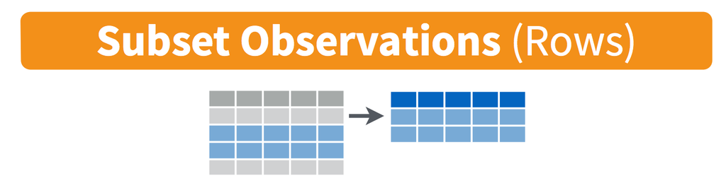

**Example 1:** Filter the cms_data data frame to find all the facilities with an overall_rating of 3.

```r
cms_data |> filter(overall_rating == 3)
```

**Output**

| id | facility_name | county | hospital_type | star_rating | no_of_surveys | response_rate | overall_rating |
| --- | --- | --- | --- | --- | --- | --- | --- |
| 040062 | MERCY HOSPITAL FORT SMITH | SEBASTIAN | Acute Care Hospital | 3 | 2506 | 35 | 3 |
| 450011 | ST JOSEPH REGIONAL HEALTH CENTER | BRAZOS | Acute Care Hospital | 3 | 1379 | 24 | 3 |
| 151317 | GREENE COUNTY GENERAL HOSPITAL | GREENE | Critical Access Hospital | 3 | 114 | 22 | 3 |
| 061327 | SOUTHWEST MEMORIAL HOSPITAL | MONTEZUMA | Critical Access Hospital | 4 | 247 | 34 | 3 |
| 490057 | SENTARA GENERAL HOSPITAL | VIRGINIA BEACH | Acute Care Hospital | 4 | 619 | 32 | 3 |
| 050704 | MISSION COMMUNITY HOSPITAL | LOS ANGELES | Acute Care Hospital | 3 | 241 | 14 | 3 |
| 100296 | DOCTORS HOSPITAL | MIAMI-DADE | Acute Care Hospital | 4 | 393 | 24 | 3 |
| 501339 | WHIDBEY GENERAL HOSPITAL | ISLAND | Critical Access Hospital | 3 | 389 | 29 | 3 |

Here we are *sending* the cms_data data frame into the function `filter()` which tests each value in overall_rating column for the value 3 and returns the rows where this condition is TRUE.

You can check the dimension (number of rows and number of columns) of the resulting data frame by sending into the `dim()` function as follows:

```r
cms_data |> filter(overall_rating == 3) |> dim()
```

**Output**

```
[1] 8 8
```

**Example 2:** Find all the facilities categorized as “Acute Care Hospital”. Here we filter on character data.

```r
cms_data |> filter(hospital_type == "Acute Care Hospital")
```

**Output**

| id | facility_name | county | hospital_type | star_rating | no_of_surveys | response_rate | overall_rating |
| --- | --- | --- | --- | --- | --- | --- | --- |
| 050424 | SCRIPPS GREEN HOSPITAL | SAN DIEGO | Acute Care Hospital | 4 | 3110 | 41 | 5 |
| 140103 | ST BERNARD HOSPITAL | COOK | Acute Care Hospital | 1 | 264 | 6 | 2 |
| 100051 | SOUTH LAKE HOSPITAL | LAKE | Acute Care Hospital | 2 | 1382 | 20 | 2 |
| 040062 | MERCY HOSPITAL FORT SMITH | SEBASTIAN | Acute Care Hospital | 3 | 2506 | 35 | 3 |
| 440048 | BAPTIST MEMORIAL HOSPITAL | SHELBY | Acute Care Hospital | 2 | 1799 | 18 | 2 |
| 450011 | ST JOSEPH REGIONAL HEALTH CENTER | BRAZOS | Acute Care Hospital | 3 | 1379 | 24 | 3 |
| 490057 | SENTARA GENERAL HOSPITAL | VIRGINIA BEACH | Acute Care Hospital | 4 | 619 | 32 | 3 |
| 110215 | PIEDMONT FAYETTE HOSPITAL | FAYETTE | Acute Care Hospital | 2 | 1714 | 21 | 2 |
| 050704 | MISSION COMMUNITY HOSPITAL | LOS ANGELES | Acute Care Hospital | 3 | 241 | 14 | 3 |
| 100296 | DOCTORS HOSPITAL | MIAMI-DADE | Acute Care Hospital | 4 | 393 | 24 | 3 |
| 440003 | SUMNER REGIONAL MEDICAL CENTER | SUMNER | Acute Care Hospital | 4 | 680 | 35 | 2 |
| 050116 | NORTHRIDGE MEDICAL CENTER | LOS ANGELES | Acute Care Hospital | 3 | 1110 | 20 | 2 |

We can use logical operators introduced before to combine multiple conditions as follows.

**Example 3:** Find all the facilities categorized as “Acute Care Hospital” and has a overall rating of above 3.

```r
cms_data |> filter(hospital_type == "Acute Care Hospital" & overall_rating > 3)
```

**Output**

| id | facility_name | county | hospital_type | star_rating | no_of_surveys | response_rate | overall_rating |
| --- | --- | --- | --- | --- | --- | --- | --- |
| 050424 | SCRIPPS GREEN HOSPITAL | SAN DIEGO | Acute Care Hospital | 4 | 3110 | 41 | 5 |

**Example 4:** Find the facilities with any rating greater than or equal to 3.

```r
cms_data |> filter(star_rating >= 3 | overall_rating >= 3)
```

**Output**

| id | facility_name | county | hospital_type | star_rating | no_of_surveys | response_rate | overall_rating |
| --- | --- | --- | --- | --- | --- | --- | --- |
| 050424 | SCRIPPS GREEN HOSPITAL | SAN DIEGO | Acute Care Hospital | 4 | 3110 | 41 | 5 |
| 040062 | MERCY HOSPITAL FORT SMITH | SEBASTIAN | Acute Care Hospital | 3 | 2506 | 35 | 3 |
| 450011 | ST JOSEPH REGIONAL HEALTH CENTER | BRAZOS | Acute Care Hospital | 3 | 1379 | 24 | 3 |
| 151317 | GREENE COUNTY GENERAL HOSPITAL | GREENE | Critical Access Hospital | 3 | 114 | 22 | 3 |
| 061327 | SOUTHWEST MEMORIAL HOSPITAL | MONTEZUMA | Critical Access Hospital | 4 | 247 | 34 | 3 |
| 490057 | SENTARA GENERAL HOSPITAL | VIRGINIA BEACH | Acute Care Hospital | 4 | 619 | 32 | 3 |
| 050704 | MISSION COMMUNITY HOSPITAL | LOS ANGELES | Acute Care Hospital | 3 | 241 | 14 | 3 |
| 100296 | DOCTORS HOSPITAL | MIAMI-DADE | Acute Care Hospital | 4 | 393 | 24 | 3 |
| 440003 | SUMNER REGIONAL MEDICAL CENTER | SUMNER | Acute Care Hospital | 4 | 680 | 35 | 2 |
| 501339 | WHIDBEY GENERAL HOSPITAL | ISLAND | Critical Access Hospital | 3 | 389 | 29 | 3 |
| 050116 | NORTHRIDGE MEDICAL CENTER | LOS ANGELES | Acute Care Hospital | 3 | 1110 | 20 | 2 |

**Example 5:** Find the facilitites with any rating greater than or equal to 3 and the response rate is above 30.

```r
cms_data |> filter(star_rating >= 3 | overall_rating >= 3 & response_rate > 30)
```

**Output**

| id | facility_name | county | hospital_type | star_rating | no_of_surveys | response_rate | overall_rating |
| --- | --- | --- | --- | --- | --- | --- | --- |
| 050424 | SCRIPPS GREEN HOSPITAL | SAN DIEGO | Acute Care Hospital | 4 | 3110 | 41 | 5 |
| 040062 | MERCY HOSPITAL FORT SMITH | SEBASTIAN | Acute Care Hospital | 3 | 2506 | 35 | 3 |
| 450011 | ST JOSEPH REGIONAL HEALTH CENTER | BRAZOS | Acute Care Hospital | 3 | 1379 | 24 | 3 |
| 151317 | GREENE COUNTY GENERAL HOSPITAL | GREENE | Critical Access Hospital | 3 | 114 | 22 | 3 |
| 061327 | SOUTHWEST MEMORIAL HOSPITAL | MONTEZUMA | Critical Access Hospital | 4 | 247 | 34 | 3 |
| 490057 | SENTARA GENERAL HOSPITAL | VIRGINIA BEACH | Acute Care Hospital | 4 | 619 | 32 | 3 |
| 050704 | MISSION COMMUNITY HOSPITAL | LOS ANGELES | Acute Care Hospital | 3 | 241 | 14 | 3 |
| 100296 | DOCTORS HOSPITAL | MIAMI-DADE | Acute Care Hospital | 4 | 393 | 24 | 3 |
| 440003 | SUMNER REGIONAL MEDICAL CENTER | SUMNER | Acute Care Hospital | 4 | 680 | 35 | 2 |
| 501339 | WHIDBEY GENERAL HOSPITAL | ISLAND | Critical Access Hospital | 3 | 389 | 29 | 3 |
| 050116 | NORTHRIDGE MEDICAL CENTER | LOS ANGELES | Acute Care Hospital | 3 | 1110 | 20 | 2 |

The output of the above command is incorrect. Recall R operator precedence where & operator precedes | operator. Therefore, the command `overall_rating >= 3 & response_rate > 30` is evaluated first. This can be verified by adding brackets around this command as follows: To fix the issue add brackets as follows:

```r
cms_data |> filter(star_rating >= 3 | (overall_rating >= 3 & response_rate > 30))
```

**Output**

| id | facility_name | county | hospital_type | star_rating | no_of_surveys | response_rate | overall_rating |
| --- | --- | --- | --- | --- | --- | --- | --- |
| 050424 | SCRIPPS GREEN HOSPITAL | SAN DIEGO | Acute Care Hospital | 4 | 3110 | 41 | 5 |
| 040062 | MERCY HOSPITAL FORT SMITH | SEBASTIAN | Acute Care Hospital | 3 | 2506 | 35 | 3 |
| 450011 | ST JOSEPH REGIONAL HEALTH CENTER | BRAZOS | Acute Care Hospital | 3 | 1379 | 24 | 3 |
| 151317 | GREENE COUNTY GENERAL HOSPITAL | GREENE | Critical Access Hospital | 3 | 114 | 22 | 3 |
| 061327 | SOUTHWEST MEMORIAL HOSPITAL | MONTEZUMA | Critical Access Hospital | 4 | 247 | 34 | 3 |
| 490057 | SENTARA GENERAL HOSPITAL | VIRGINIA BEACH | Acute Care Hospital | 4 | 619 | 32 | 3 |
| 050704 | MISSION COMMUNITY HOSPITAL | LOS ANGELES | Acute Care Hospital | 3 | 241 | 14 | 3 |
| 100296 | DOCTORS HOSPITAL | MIAMI-DADE | Acute Care Hospital | 4 | 393 | 24 | 3 |
| 440003 | SUMNER REGIONAL MEDICAL CENTER | SUMNER | Acute Care Hospital | 4 | 680 | 35 | 2 |
| 501339 | WHIDBEY GENERAL HOSPITAL | ISLAND | Critical Access Hospital | 3 | 389 | 29 | 3 |
| 050116 | NORTHRIDGE MEDICAL CENTER | LOS ANGELES | Acute Care Hospital | 3 | 1110 | 20 | 2 |

To fix the issue add brackets as follows:

```r
cms_data |> filter((star_rating >= 3 | overall_rating >= 3) & response_rate > 30)
```

**Output**

| id | facility_name | county | hospital_type | star_rating | no_of_surveys | response_rate | overall_rating |
| --- | --- | --- | --- | --- | --- | --- | --- |
| 050424 | SCRIPPS GREEN HOSPITAL | SAN DIEGO | Acute Care Hospital | 4 | 3110 | 41 | 5 |
| 040062 | MERCY HOSPITAL FORT SMITH | SEBASTIAN | Acute Care Hospital | 3 | 2506 | 35 | 3 |
| 061327 | SOUTHWEST MEMORIAL HOSPITAL | MONTEZUMA | Critical Access Hospital | 4 | 247 | 34 | 3 |
| 490057 | SENTARA GENERAL HOSPITAL | VIRGINIA BEACH | Acute Care Hospital | 4 | 619 | 32 | 3 |
| 440003 | SUMNER REGIONAL MEDICAL CENTER | SUMNER | Acute Care Hospital | 4 | 680 | 35 | 2 |

This results in the correct output.

#### `%in%` helper

The `%in%` function is used to determine whether elements of one vector are present in another vector. It returns a logical vector indicating whether each element of the first vector is found in the second vector.

When we want to filter a subset of rows that may contain multiple different values, it’s more efficient to provide a vector of the values of interest instead of combining multiple OR commands.

**Example 6:** Retrieve a subset of facilities that have an odd number of overall rating.

```r
cms_data |> filter(overall_rating %in% c(1, 3, 5))
```

**Output**

| id | facility_name | county | hospital_type | star_rating | no_of_surveys | response_rate | overall_rating |
| --- | --- | --- | --- | --- | --- | --- | --- |
| 050424 | SCRIPPS GREEN HOSPITAL | SAN DIEGO | Acute Care Hospital | 4 | 3110 | 41 | 5 |
| 040062 | MERCY HOSPITAL FORT SMITH | SEBASTIAN | Acute Care Hospital | 3 | 2506 | 35 | 3 |
| 450011 | ST JOSEPH REGIONAL HEALTH CENTER | BRAZOS | Acute Care Hospital | 3 | 1379 | 24 | 3 |
| 151317 | GREENE COUNTY GENERAL HOSPITAL | GREENE | Critical Access Hospital | 3 | 114 | 22 | 3 |
| 061327 | SOUTHWEST MEMORIAL HOSPITAL | MONTEZUMA | Critical Access Hospital | 4 | 247 | 34 | 3 |
| 490057 | SENTARA GENERAL HOSPITAL | VIRGINIA BEACH | Acute Care Hospital | 4 | 619 | 32 | 3 |
| 050704 | MISSION COMMUNITY HOSPITAL | LOS ANGELES | Acute Care Hospital | 3 | 241 | 14 | 3 |
| 100296 | DOCTORS HOSPITAL | MIAMI-DADE | Acute Care Hospital | 4 | 393 | 24 | 3 |
| 501339 | WHIDBEY GENERAL HOSPITAL | ISLAND | Critical Access Hospital | 3 | 389 | 29 | 3 |

#### `str_detect` function

The `str_detect()` function is part of the `stringr` package and is used for pattern matching within strings. It allows you to search for a specific pattern or regular expression (discussed later) within a character vector or string.

**Example 1:** Find all the facilities that contains GENERAL in their name from the cms_data data frame.

```r
cms_data |> filter(
  str_detect(facility_name, 'GENERAL')
  )
```

**Output**

| id | facility_name | county | hospital_type | star_rating | no_of_surveys | response_rate | overall_rating |
| --- | --- | --- | --- | --- | --- | --- | --- |
| 151317 | GREENE COUNTY GENERAL HOSPITAL | GREENE | Critical Access Hospital | 3 | 114 | 22 | 3 |
| 490057 | SENTARA GENERAL HOSPITAL | VIRGINIA BEACH | Acute Care Hospital | 4 | 619 | 32 | 3 |
| 501339 | WHIDBEY GENERAL HOSPITAL | ISLAND | Critical Access Hospital | 3 | 389 | 29 | 3 |

### `select()`

The `select()` function returns a subset of the variables or columns.

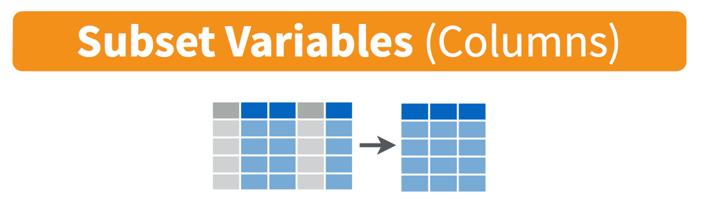

This function can accept column names (even without quotation marks) or the column position number starting from the left. Unlike in base R (we explore before), commands within the brackets in `select()` do not need to be concatenated using `c()`.

**Example 1:** Extract the facility name, hospital type and overall rating columns from cms_data data frame.

```r
cms_data |> select(facility_name, hospital_type, overall_rating)
```

**Output**

| facility_name | hospital_type | overall_rating |
| --- | --- | --- |
| SCRIPPS GREEN HOSPITAL | Acute Care Hospital | 5 |
| ST BERNARD HOSPITAL | Acute Care Hospital | 2 |
| SOUTH LAKE HOSPITAL | Acute Care Hospital | 2 |
| MERCY HOSPITAL FORT SMITH | Acute Care Hospital | 3 |
| BAPTIST MEMORIAL HOSPITAL | Acute Care Hospital | 2 |
| ST JOSEPH REGIONAL HEALTH CENTER | Acute Care Hospital | 3 |
| GREENE COUNTY GENERAL HOSPITAL | Critical Access Hospital | 3 |
| SOUTHWEST MEMORIAL HOSPITAL | Critical Access Hospital | 3 |
| SENTARA GENERAL HOSPITAL | Acute Care Hospital | 3 |
| PIEDMONT FAYETTE HOSPITAL | Acute Care Hospital | 2 |
| MISSION COMMUNITY HOSPITAL | Acute Care Hospital | 3 |
| DOCTORS HOSPITAL | Acute Care Hospital | 3 |
| SUMNER REGIONAL MEDICAL CENTER | Acute Care Hospital | 2 |
| WHIDBEY GENERAL HOSPITAL | Critical Access Hospital | 3 |
| NORTHRIDGE MEDICAL CENTER | Acute Care Hospital | 2 |

Using column positions:

```r
cms_data |> select(2, 4, 8)
```

**Output**

| facility_name | hospital_type | overall_rating |
| --- | --- | --- |
| SCRIPPS GREEN HOSPITAL | Acute Care Hospital | 5 |
| ST BERNARD HOSPITAL | Acute Care Hospital | 2 |
| SOUTH LAKE HOSPITAL | Acute Care Hospital | 2 |
| MERCY HOSPITAL FORT SMITH | Acute Care Hospital | 3 |
| BAPTIST MEMORIAL HOSPITAL | Acute Care Hospital | 2 |
| ST JOSEPH REGIONAL HEALTH CENTER | Acute Care Hospital | 3 |
| GREENE COUNTY GENERAL HOSPITAL | Critical Access Hospital | 3 |
| SOUTHWEST MEMORIAL HOSPITAL | Critical Access Hospital | 3 |
| SENTARA GENERAL HOSPITAL | Acute Care Hospital | 3 |
| PIEDMONT FAYETTE HOSPITAL | Acute Care Hospital | 2 |
| MISSION COMMUNITY HOSPITAL | Acute Care Hospital | 3 |
| DOCTORS HOSPITAL | Acute Care Hospital | 3 |
| SUMNER REGIONAL MEDICAL CENTER | Acute Care Hospital | 2 |
| WHIDBEY GENERAL HOSPITAL | Critical Access Hospital | 3 |
| NORTHRIDGE MEDICAL CENTER | Acute Care Hospital | 2 |

We can use the ‘-’ symbol to extract all columns except for specific ones:

```r
cms_data |> dplyr::select(-id, -county_name, -star_rating, -no_of_surveys, -response_rate)
```

**Output**

[output not shown]

Or use a combination of column names and positions:

```r
cms_data |> select(2, 4, overall_rating)
```

**Output**

| facility_name | hospital_type | overall_rating |
| --- | --- | --- |
| SCRIPPS GREEN HOSPITAL | Acute Care Hospital | 5 |
| ST BERNARD HOSPITAL | Acute Care Hospital | 2 |
| SOUTH LAKE HOSPITAL | Acute Care Hospital | 2 |
| MERCY HOSPITAL FORT SMITH | Acute Care Hospital | 3 |
| BAPTIST MEMORIAL HOSPITAL | Acute Care Hospital | 2 |
| ST JOSEPH REGIONAL HEALTH CENTER | Acute Care Hospital | 3 |
| GREENE COUNTY GENERAL HOSPITAL | Critical Access Hospital | 3 |
| SOUTHWEST MEMORIAL HOSPITAL | Critical Access Hospital | 3 |
| SENTARA GENERAL HOSPITAL | Acute Care Hospital | 3 |
| PIEDMONT FAYETTE HOSPITAL | Acute Care Hospital | 2 |
| MISSION COMMUNITY HOSPITAL | Acute Care Hospital | 3 |
| DOCTORS HOSPITAL | Acute Care Hospital | 3 |
| SUMNER REGIONAL MEDICAL CENTER | Acute Care Hospital | 2 |
| WHIDBEY GENERAL HOSPITAL | Critical Access Hospital | 3 |
| NORTHRIDGE MEDICAL CENTER | Acute Care Hospital | 2 |

#### Useful helper functions

The select helper functions (check `?select_helpers`) are a set of convenience functions provided by the `dplyr` package. These functions offer shortcuts for selecting columns based on specific criteria or patterns, making it easier to work with data frames.

Some commonly used select helper functions include:

1. **`starts_with()`:** selects columns that start with a specified prefix.

```r
cms_data |> select(starts_with('s'))
```

**Output**

| star_rating |
| --- |
| 4 |
| 1 |
| 2 |
| 3 |
| 2 |
| 3 |
| 3 |
| 4 |
| 4 |
| 2 |
| 3 |
| 4 |
| 4 |
| 3 |
| 3 |

2. **`ends_with()`:** selects columns that end with a specified suffix.

```r
cms_data |> select(ends_with('g'))
```

**Output**

| star_rating | overall_rating |
| --- | --- |
| 4 | 5 |
| 1 | 2 |
| 2 | 2 |
| 3 | 3 |
| 2 | 2 |
| 3 | 3 |
| 3 | 3 |
| 4 | 3 |
| 4 | 3 |
| 2 | 2 |
| 3 | 3 |
| 4 | 3 |
| 4 | 2 |
| 3 | 3 |
| 3 | 2 |

3. **`contains()`:** selects columns that contain a specified substring.

```r
cms_data |> select(contains('name'))
```

**Output**

| facility_name |
| --- |
| SCRIPPS GREEN HOSPITAL |
| ST BERNARD HOSPITAL |
| SOUTH LAKE HOSPITAL |
| MERCY HOSPITAL FORT SMITH |
| BAPTIST MEMORIAL HOSPITAL |
| ST JOSEPH REGIONAL HEALTH CENTER |
| GREENE COUNTY GENERAL HOSPITAL |
| SOUTHWEST MEMORIAL HOSPITAL |
| SENTARA GENERAL HOSPITAL |
| PIEDMONT FAYETTE HOSPITAL |
| MISSION COMMUNITY HOSPITAL |
| DOCTORS HOSPITAL |
| SUMNER REGIONAL MEDICAL CENTER |
| WHIDBEY GENERAL HOSPITAL |
| NORTHRIDGE MEDICAL CENTER |

```r
cms_data |> select(contains('f'))
```

**Output**

| facility_name | no_of_surveys |
| --- | --- |
| SCRIPPS GREEN HOSPITAL | 3110 |
| ST BERNARD HOSPITAL | 264 |
| SOUTH LAKE HOSPITAL | 1382 |
| MERCY HOSPITAL FORT SMITH | 2506 |
| BAPTIST MEMORIAL HOSPITAL | 1799 |
| ST JOSEPH REGIONAL HEALTH CENTER | 1379 |
| GREENE COUNTY GENERAL HOSPITAL | 114 |
| SOUTHWEST MEMORIAL HOSPITAL | 247 |
| SENTARA GENERAL HOSPITAL | 619 |
| PIEDMONT FAYETTE HOSPITAL | 1714 |
| MISSION COMMUNITY HOSPITAL | 241 |
| DOCTORS HOSPITAL | 393 |
| SUMNER REGIONAL MEDICAL CENTER | 680 |
| WHIDBEY GENERAL HOSPITAL | 389 |
| NORTHRIDGE MEDICAL CENTER | 1110 |

4. **`matches()`:** selects columns that match a specified regular expression pattern.

```r
cms_data |> select(
  matches('[a-z]_[a-z]{4}$')
  )
```

**Output**

| facility_name | hospital_type | response_rate |
| --- | --- | --- |
| SCRIPPS GREEN HOSPITAL | Acute Care Hospital | 41 |
| ST BERNARD HOSPITAL | Acute Care Hospital | 6 |
| SOUTH LAKE HOSPITAL | Acute Care Hospital | 20 |
| MERCY HOSPITAL FORT SMITH | Acute Care Hospital | 35 |
| BAPTIST MEMORIAL HOSPITAL | Acute Care Hospital | 18 |
| ST JOSEPH REGIONAL HEALTH CENTER | Acute Care Hospital | 24 |
| GREENE COUNTY GENERAL HOSPITAL | Critical Access Hospital | 22 |
| SOUTHWEST MEMORIAL HOSPITAL | Critical Access Hospital | 34 |
| SENTARA GENERAL HOSPITAL | Acute Care Hospital | 32 |
| PIEDMONT FAYETTE HOSPITAL | Acute Care Hospital | 21 |
| MISSION COMMUNITY HOSPITAL | Acute Care Hospital | 14 |
| DOCTORS HOSPITAL | Acute Care Hospital | 24 |
| SUMNER REGIONAL MEDICAL CENTER | Acute Care Hospital | 35 |
| WHIDBEY GENERAL HOSPITAL | Critical Access Hospital | 29 |
| NORTHRIDGE MEDICAL CENTER | Acute Care Hospital | 20 |

Here, the regular expression `[a-z]_[a-z]{4}$` can be broken down into smaller chunks for better understanding:

- `[a-z]` matches a set of lowercase characters from ‘a’ to ‘z’.
- `_` matches an underscore.
- `[a-z]{4}` matches any four lowercase characters from ‘a’ to ‘z’.

If you’re unfamiliar with regular expressions, you can skip this section for now. However, interested readers can find many online resources to learn about regular expressions. One of my favorite online tools for building and testing regular expressions is https://regexr.com. You can use this tool to test the correctness of a regular expression.

5. **`num_range()`:** selects columns based on a numeric range.

Let’s use the count data frame for this example. First read the csv file: GSE60450_normalized_data.csv.

```r
counts <- read_csv("data/GSE60450_normalized_data.csv")
colnames(counts)
```

**Output**

```
 [1] "X"           "gene_symbol" "GSM1480291"  "GSM1480292"  "GSM1480293"
 [6] "GSM1480294"  "GSM1480295"  "GSM1480296"  "GSM1480297"  "GSM1480298"
[11] "GSM1480299"  "GSM1480300"  "GSM1480301"  "GSM1480302"
```

To select the samples from GSM1480297 to GSM1480300:

```r
counts |> select(
  num_range(prefix = "GSM1480", 297:300)
  )
```

**Output**

| GSM1480297 | GSM1480298 | GSM1480299 | GSM1480300 |
| --- | --- | --- | --- |
| 10.59006 | 14.88337 | 7.57182 | 7.05763 |
| 95.67017 | 100.73912 | 78.07470 | 59.35009 |
| 0.00000 | 0.00000 | 0.00000 | 0.00000 |
| 125.00263 | 102.99289 | 110.64124 | 97.98130 |
| 0.00000 | 0.08505 | 0.07726 | 0.08255 |
| 33.84822 | 36.91075 | 27.46715 | 31.36722 |
| 0.00000 | 0.00000 | 0.00000 | 0.00000 |
| 281.97525 | 241.83343 | 227.84988 | 232.81909 |
| 62.62120 | 61.82975 | 49.98944 | 42.01557 |
| 17.98312 | 13.69270 | 9.00119 | 9.69908 |
| 51.79137 | 49.49782 | 52.84819 | 47.00956 |
| 50.07299 | 50.94364 | 45.04458 | 36.89776 |
| 147.58143 | 128.20957 | 168.08661 | 133.35197 |
| 52.83040 | 84.66509 | 323.54064 | 485.86178 |
| 0.07992 | 0.00000 | 0.00000 | 0.00000 |
| 0.00000 | 0.00000 | 0.03863 | 0.00000 |
| 102.26398 | 81.05056 | 115.31568 | 138.38724 |
| 0.03996 | 0.00000 | 0.00000 | 0.00000 |
| 0.00000 | 0.00000 | 0.00000 | 0.00000 |
| 14.02683 | 11.56650 | 12.13036 | 12.21671 |

6. **`all_of()`:** selects columns specified by character vector.

```r
cms_data |> select(
  all_of(c("star_rating", "no_of_surveys", "response_rate", "no_column_by_this_name"))
  )
```

```
Error in `all_of()`:
! Can't subset columns that don't exist.
✖ Column `no_column_by_this_name` doesn't exist.
```

When using `all_of()`, all the names provided by the vector must be present in the data frame. Otherwise, it will result in an error, as shown above.

```r
cms_data |> select(
  all_of(c("star_rating", "no_of_surveys", "response_rate"))
  )
```

**Output**

| star_rating | no_of_surveys | response_rate |
| --- | --- | --- |
| 4 | 3110 | 41 |
| 1 | 264 | 6 |
| 2 | 1382 | 20 |
| 3 | 2506 | 35 |
| 2 | 1799 | 18 |
| 3 | 1379 | 24 |
| 3 | 114 | 22 |
| 4 | 247 | 34 |
| 4 | 619 | 32 |
| 2 | 1714 | 21 |
| 3 | 241 | 14 |
| 4 | 393 | 24 |
| 4 | 680 | 35 |
| 3 | 389 | 29 |
| 3 | 1110 | 20 |

7. **`any_of()`:** selects columns specified by character vector, allowing any of them to be present.

```r
cms_data |> select(
  any_of(c("star_rating", "no_of_surveys", "response_rate", "no_column_by_this_name"))
  )
```

**Output**

| star_rating | no_of_surveys | response_rate |
| --- | --- | --- |
| 4 | 3110 | 41 |
| 1 | 264 | 6 |
| 2 | 1382 | 20 |
| 3 | 2506 | 35 |
| 2 | 1799 | 18 |
| 3 | 1379 | 24 |
| 3 | 114 | 22 |
| 4 | 247 | 34 |
| 4 | 619 | 32 |
| 2 | 1714 | 21 |
| 3 | 241 | 14 |
| 4 | 393 | 24 |
| 4 | 680 | 35 |
| 3 | 389 | 29 |
| 3 | 1110 | 20 |

8. **`everything()`:** Selects all columns.

This function returns all column names that have not been specified. It is often used when reordering all columns in a dataframe:

```r
cms_data |> select(5, 8, 2, everything())
```

**Output**

| star_rating | overall_rating | facility_name | id | county | hospital_type | no_of_surveys | response_rate |
| --- | --- | --- | --- | --- | --- | --- | --- |
| 4 | 5 | SCRIPPS GREEN HOSPITAL | 050424 | SAN DIEGO | Acute Care Hospital | 3110 | 41 |
| 1 | 2 | ST BERNARD HOSPITAL | 140103 | COOK | Acute Care Hospital | 264 | 6 |
| 2 | 2 | SOUTH LAKE HOSPITAL | 100051 | LAKE | Acute Care Hospital | 1382 | 20 |
| 3 | 3 | MERCY HOSPITAL FORT SMITH | 040062 | SEBASTIAN | Acute Care Hospital | 2506 | 35 |
| 2 | 2 | BAPTIST MEMORIAL HOSPITAL | 440048 | SHELBY | Acute Care Hospital | 1799 | 18 |
| 3 | 3 | ST JOSEPH REGIONAL HEALTH CENTER | 450011 | BRAZOS | Acute Care Hospital | 1379 | 24 |
| 3 | 3 | GREENE COUNTY GENERAL HOSPITAL | 151317 | GREENE | Critical Access Hospital | 114 | 22 |
| 4 | 3 | SOUTHWEST MEMORIAL HOSPITAL | 061327 | MONTEZUMA | Critical Access Hospital | 247 | 34 |
| 4 | 3 | SENTARA GENERAL HOSPITAL | 490057 | VIRGINIA BEACH | Acute Care Hospital | 619 | 32 |
| 2 | 2 | PIEDMONT FAYETTE HOSPITAL | 110215 | FAYETTE | Acute Care Hospital | 1714 | 21 |
| 3 | 3 | MISSION COMMUNITY HOSPITAL | 050704 | LOS ANGELES | Acute Care Hospital | 241 | 14 |
| 4 | 3 | DOCTORS HOSPITAL | 100296 | MIAMI-DADE | Acute Care Hospital | 393 | 24 |
| 4 | 2 | SUMNER REGIONAL MEDICAL CENTER | 440003 | SUMNER | Acute Care Hospital | 680 | 35 |
| 3 | 3 | WHIDBEY GENERAL HOSPITAL | 501339 | ISLAND | Critical Access Hospital | 389 | 29 |
| 3 | 2 | NORTHRIDGE MEDICAL CENTER | 050116 | LOS ANGELES | Acute Care Hospital | 1110 | 20 |

Here the dimensions of the dataframe is not changed, merely the column order.

You can combine multiple helper functions to create more complex selection criteria. Additionally, you can use the ‘-’ symbol in front of the helper function to exclude the matched columns.

For example try the following examples:

```r
cms_data |> select(starts_with('i'), contains('rating'))
cms_data |> select(ends_with("type"), everything(), -1, -3)
```

### `mutate()`

The `mutate()` function adds new columns of data, thus ‘mutating’ the contents and dimensions of the input data frame.

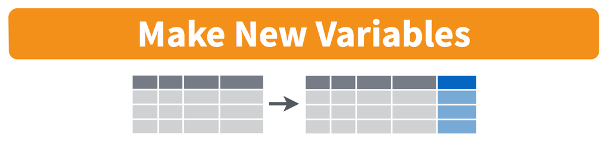

**Example 1:** Calculate the total number of patients or visitors who responded to the survey in each facility (i.e, $\text{response rate } = \frac{\text{number of responses}}{\text{total number of surveys}} \times 100$).

Here we use the `round()` function to round off the result to the closest integer or numeric value as number of responses cannot contain decimal values.

```r
cms_data |>
  mutate(no_of_responses = round(no_of_surveys * response_rate / 100))
```

**Output**

[output not shown]

This creates a new column at the end of the data frame named ‘no_of_responses’ and computes the total number of responses. Because the number of columns is expanding, we can reduce the number of columns displayed using the `select()` function.

To do this, we need to use *chaining* which is discussed below.

### Chaining functions

R *chaining* allows you to streamline your data analysis workflow by sequentially applying multiple operations to your data using the pipe operator `|>`. We often need to perform several data manipulation or analysis operations in a sequence. Chaining allows you to apply these operations one after the other in a clear and concise manner.

Here’s a basic template for chaining operations using the pipe operator `|>`:

```r
result <- data |>
    operation1(...) |>
    operation2(...) |>
    operation3(...) |>
    ...
    operationN(...)
```

In this template:

- `data` represents the input data frame or object.
- `operation1`, `operation2`, …, `operationN` represent the functions or operations you want to apply sequentially to the data.For example: `select()`, `filter()` or `mutate()` functions.
- `...` represents any additional arguments or parameters that may be passed to each operation.

Each operation takes the output of the previous operation as its input, making it easy to chain multiple operations together. This improves the readability of your code by organizing operations in a left-to-right fashion and it avoids creating intermediate variables to store the results of each operation.

### `mutate()` continued

Let’s use chaining to combine both `select()` and `mutate()` operations for the previos example:

```r
cms_data |>
  select(facility_name, no_of_surveys, response_rate) |>
  mutate(no_of_responses = round(no_of_surveys * response_rate / 100))
```

**Output**

[output not shown]

### `summarise()`

The `summarise()` function creates individual summary statistics from larger data sets.

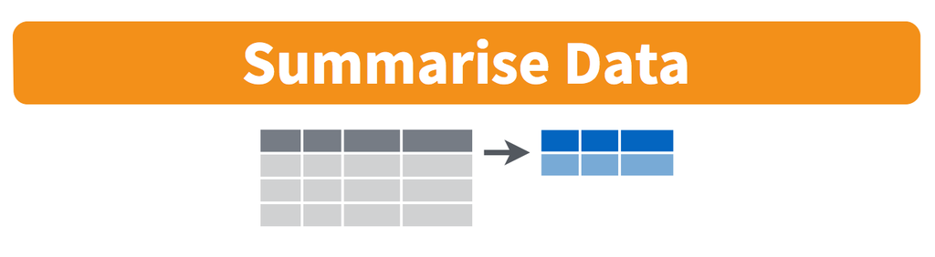

The output of `summarise()/summarize()` differs qualitatively from the input. It results in a smaller dataframe with a reduced representation of the original data. While not strictly necessary, it’s advisable to assign new column names for the summary statistics generated by this function. This practice enhances clarity and organization in your data analysis workflow.

**Example 1:** Calculate the mean number of surveys.

```r
cms_data |>
  summarise(mean_no_of_surveys = mean(no_of_surveys))
```

**Output**

| mean_no_of_surveys |
| --- |
| 1063.133 |

This results in a data frame of size 1 row $\times$ 1 col. We can create additional summary statistics by adding them in a comma-separated sequence as follows:

```r
cms_data |>
  summarise(mean_no_of_surveys = mean(no_of_surveys),
            min_no_of_surveys = min(no_of_surveys),
            max_no_of_surveys = max(no_of_surveys),
            tot_no_of_surveys = sum(no_of_surveys))
```

**Output**

| mean_no_of_surveys | min_no_of_surveys | max_no_of_surveys | tot_no_of_surveys |
| --- | --- | --- | --- |
| 1063.133 | 114 | 3110 | 15947 |

#### `n()` helper function

This function counts the number of observations in a dataset. It does not take any arguments, but simply counts the rows.

```r
cms_data |>
  summarise(mean_no_of_surveys = mean(no_of_surveys),
            min_no_of_surveys = min(no_of_surveys),
            max_no_of_surveys = max(no_of_surveys),
            tot_no_of_surveys = sum(no_of_surveys),
            n_rows = n())
```

**Output**

| mean_no_of_surveys | min_no_of_surveys | max_no_of_surveys | tot_no_of_surveys | n_rows |
| --- | --- | --- | --- | --- |
| 1063.133 | 114 | 3110 | 15947 | 15 |

### `arrange()`

The `arrange()` function orders rows based on the values in a given column.

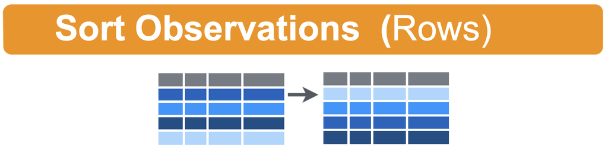

**Example 1:** Order the facilities based on the county.

```r
cms_data |>
  arrange(county)
```

**Output**

| id | facility_name | county | hospital_type | star_rating | no_of_surveys | response_rate | overall_rating |
| --- | --- | --- | --- | --- | --- | --- | --- |
| 450011 | ST JOSEPH REGIONAL HEALTH CENTER | BRAZOS | Acute Care Hospital | 3 | 1379 | 24 | 3 |
| 140103 | ST BERNARD HOSPITAL | COOK | Acute Care Hospital | 1 | 264 | 6 | 2 |
| 110215 | PIEDMONT FAYETTE HOSPITAL | FAYETTE | Acute Care Hospital | 2 | 1714 | 21 | 2 |
| 151317 | GREENE COUNTY GENERAL HOSPITAL | GREENE | Critical Access Hospital | 3 | 114 | 22 | 3 |
| 501339 | WHIDBEY GENERAL HOSPITAL | ISLAND | Critical Access Hospital | 3 | 389 | 29 | 3 |
| 100051 | SOUTH LAKE HOSPITAL | LAKE | Acute Care Hospital | 2 | 1382 | 20 | 2 |
| 050704 | MISSION COMMUNITY HOSPITAL | LOS ANGELES | Acute Care Hospital | 3 | 241 | 14 | 3 |
| 050116 | NORTHRIDGE MEDICAL CENTER | LOS ANGELES | Acute Care Hospital | 3 | 1110 | 20 | 2 |
| 100296 | DOCTORS HOSPITAL | MIAMI-DADE | Acute Care Hospital | 4 | 393 | 24 | 3 |
| 061327 | SOUTHWEST MEMORIAL HOSPITAL | MONTEZUMA | Critical Access Hospital | 4 | 247 | 34 | 3 |
| 050424 | SCRIPPS GREEN HOSPITAL | SAN DIEGO | Acute Care Hospital | 4 | 3110 | 41 | 5 |
| 040062 | MERCY HOSPITAL FORT SMITH | SEBASTIAN | Acute Care Hospital | 3 | 2506 | 35 | 3 |
| 440048 | BAPTIST MEMORIAL HOSPITAL | SHELBY | Acute Care Hospital | 2 | 1799 | 18 | 2 |
| 440003 | SUMNER REGIONAL MEDICAL CENTER | SUMNER | Acute Care Hospital | 4 | 680 | 35 | 2 |
| 490057 | SENTARA GENERAL HOSPITAL | VIRGINIA BEACH | Acute Care Hospital | 4 | 619 | 32 | 3 |

**Example 2:** Sort the facilities based on the overall rating first and then by response rate.

```r
cms_data |>
  arrange(overall_rating, response_rate)
```

**Output**

| id | facility_name | county | hospital_type | star_rating | no_of_surveys | response_rate | overall_rating |
| --- | --- | --- | --- | --- | --- | --- | --- |
| 140103 | ST BERNARD HOSPITAL | COOK | Acute Care Hospital | 1 | 264 | 6 | 2 |
| 440048 | BAPTIST MEMORIAL HOSPITAL | SHELBY | Acute Care Hospital | 2 | 1799 | 18 | 2 |
| 100051 | SOUTH LAKE HOSPITAL | LAKE | Acute Care Hospital | 2 | 1382 | 20 | 2 |
| 050116 | NORTHRIDGE MEDICAL CENTER | LOS ANGELES | Acute Care Hospital | 3 | 1110 | 20 | 2 |
| 110215 | PIEDMONT FAYETTE HOSPITAL | FAYETTE | Acute Care Hospital | 2 | 1714 | 21 | 2 |
| 440003 | SUMNER REGIONAL MEDICAL CENTER | SUMNER | Acute Care Hospital | 4 | 680 | 35 | 2 |
| 050704 | MISSION COMMUNITY HOSPITAL | LOS ANGELES | Acute Care Hospital | 3 | 241 | 14 | 3 |
| 151317 | GREENE COUNTY GENERAL HOSPITAL | GREENE | Critical Access Hospital | 3 | 114 | 22 | 3 |
| 450011 | ST JOSEPH REGIONAL HEALTH CENTER | BRAZOS | Acute Care Hospital | 3 | 1379 | 24 | 3 |
| 100296 | DOCTORS HOSPITAL | MIAMI-DADE | Acute Care Hospital | 4 | 393 | 24 | 3 |
| 501339 | WHIDBEY GENERAL HOSPITAL | ISLAND | Critical Access Hospital | 3 | 389 | 29 | 3 |
| 490057 | SENTARA GENERAL HOSPITAL | VIRGINIA BEACH | Acute Care Hospital | 4 | 619 | 32 | 3 |
| 061327 | SOUTHWEST MEMORIAL HOSPITAL | MONTEZUMA | Critical Access Hospital | 4 | 247 | 34 | 3 |
| 040062 | MERCY HOSPITAL FORT SMITH | SEBASTIAN | Acute Care Hospital | 3 | 2506 | 35 | 3 |
| 050424 | SCRIPPS GREEN HOSPITAL | SAN DIEGO | Acute Care Hospital | 4 | 3110 | 41 | 5 |

#### `desc()` helper function

This function is used to sort data in descending order.

**Example 3:** Sort the facilities in descending order based on the number of surveys

```r
cms_data |>
  arrange(desc(no_of_surveys))
```

**Output**

| id | facility_name | county | hospital_type | star_rating | no_of_surveys | response_rate | overall_rating |
| --- | --- | --- | --- | --- | --- | --- | --- |
| 050424 | SCRIPPS GREEN HOSPITAL | SAN DIEGO | Acute Care Hospital | 4 | 3110 | 41 | 5 |
| 040062 | MERCY HOSPITAL FORT SMITH | SEBASTIAN | Acute Care Hospital | 3 | 2506 | 35 | 3 |
| 440048 | BAPTIST MEMORIAL HOSPITAL | SHELBY | Acute Care Hospital | 2 | 1799 | 18 | 2 |
| 110215 | PIEDMONT FAYETTE HOSPITAL | FAYETTE | Acute Care Hospital | 2 | 1714 | 21 | 2 |
| 100051 | SOUTH LAKE HOSPITAL | LAKE | Acute Care Hospital | 2 | 1382 | 20 | 2 |
| 450011 | ST JOSEPH REGIONAL HEALTH CENTER | BRAZOS | Acute Care Hospital | 3 | 1379 | 24 | 3 |
| 050116 | NORTHRIDGE MEDICAL CENTER | LOS ANGELES | Acute Care Hospital | 3 | 1110 | 20 | 2 |
| 440003 | SUMNER REGIONAL MEDICAL CENTER | SUMNER | Acute Care Hospital | 4 | 680 | 35 | 2 |
| 490057 | SENTARA GENERAL HOSPITAL | VIRGINIA BEACH | Acute Care Hospital | 4 | 619 | 32 | 3 |
| 100296 | DOCTORS HOSPITAL | MIAMI-DADE | Acute Care Hospital | 4 | 393 | 24 | 3 |
| 501339 | WHIDBEY GENERAL HOSPITAL | ISLAND | Critical Access Hospital | 3 | 389 | 29 | 3 |
| 140103 | ST BERNARD HOSPITAL | COOK | Acute Care Hospital | 1 | 264 | 6 | 2 |
| 061327 | SOUTHWEST MEMORIAL HOSPITAL | MONTEZUMA | Critical Access Hospital | 4 | 247 | 34 | 3 |
| 050704 | MISSION COMMUNITY HOSPITAL | LOS ANGELES | Acute Care Hospital | 3 | 241 | 14 | 3 |
| 151317 | GREENE COUNTY GENERAL HOSPITAL | GREENE | Critical Access Hospital | 3 | 114 | 22 | 3 |

### `group_by()`

The `group_by()` function groups data by one or more variables. It allows us to create sub groups based on labels in a particular column and to run subsequent functions or operations on all sub groups.

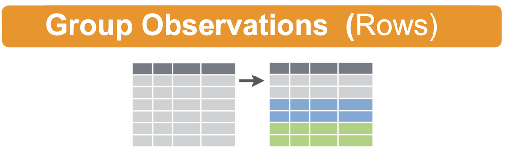

The `group_by()` function essentially partitions the data into separate subsets, each corresponding to a distinct category in a specified column. To observe this in action, inspect the structure using `str()` of the cms_data dataset before and after grouping:

```r
cms_data |> str()
```

**Output**

```
spc_tbl_ [15 × 8] (S3: spec_tbl_df/tbl_df/tbl/data.frame)
 $ id            : chr [1:15] "050424" "140103" "100051" "040062" ...
 $ facility_name : chr [1:15] "SCRIPPS GREEN HOSPITAL" "ST BERNARD HOSPITAL" "SOUTH LAKE HOSPITAL" "MERCY HOSPITAL FORT SMITH" ...
 $ county        : chr [1:15] "SAN DIEGO" "COOK" "LAKE" "SEBASTIAN" ...
 $ hospital_type : chr [1:15] "Acute Care Hospital" "Acute Care Hospital" "Acute Care Hospital" "Acute Care Hospital" ...
 $ star_rating   : num [1:15] 4 1 2 3 2 3 3 4 4 2 ...
 $ no_of_surveys : num [1:15] 3110 264 1382 2506 1799 ...
 $ response_rate : num [1:15] 41 6 20 35 18 24 22 34 32 21 ...
 $ overall_rating: num [1:15] 5 2 2 3 2 3 3 3 3 2 ...
 - attr(*, "spec")=
  .. cols(
  ..   ID = col_character(),
  ..   `Facility Name` = col_character(),
  ..   County = col_character(),
  ..   `Hospital Type` = col_character(),
  ..   `Star Rating` = col_double(),
  ..   `No of Surveys` = col_double(),
  ..   `Response Rate` = col_double(),
  ..   `Overall Rating` = col_double()
  .. )
 - attr(*, "problems")=<externalptr>
```

```r
cms_data |> group_by(hospital_type) |> str()
```

**Output**

```
gropd_df [15 × 8] (S3: grouped_df/tbl_df/tbl/data.frame)
 $ id            : chr [1:15] "050424" "140103" "100051" "040062" ...
 $ facility_name : chr [1:15] "SCRIPPS GREEN HOSPITAL" "ST BERNARD HOSPITAL" "SOUTH LAKE HOSPITAL" "MERCY HOSPITAL FORT SMITH" ...
 $ county        : chr [1:15] "SAN DIEGO" "COOK" "LAKE" "SEBASTIAN" ...
 $ hospital_type : chr [1:15] "Acute Care Hospital" "Acute Care Hospital" "Acute Care Hospital" "Acute Care Hospital" ...
 $ star_rating   : num [1:15] 4 1 2 3 2 3 3 4 4 2 ...
 $ no_of_surveys : num [1:15] 3110 264 1382 2506 1799 ...
 $ response_rate : num [1:15] 41 6 20 35 18 24 22 34 32 21 ...
 $ overall_rating: num [1:15] 5 2 2 3 2 3 3 3 3 2 ...
 - attr(*, "spec")=
  .. cols(
  ..   ID = col_character(),
  ..   `Facility Name` = col_character(),
  ..   County = col_character(),
  ..   `Hospital Type` = col_character(),
  ..   `Star Rating` = col_double(),
  ..   `No of Surveys` = col_double(),
  ..   `Response Rate` = col_double(),
  ..   `Overall Rating` = col_double()
  .. )
 - attr(*, "problems")=<externalptr>
 - attr(*, "groups")= tibble [2 × 2] (S3: tbl_df/tbl/data.frame)
  ..$ hospital_type: chr [1:2] "Acute Care Hospital" "Critical Access Hospital"
  ..$ .rows        : list<int> [1:2]
  .. ..$ : int [1:12] 1 2 3 4 5 6 9 10 11 12 ...
  .. ..$ : int [1:3] 7 8 14
  .. ..@ ptype: int(0)
  ..- attr(*, ".drop")= logi TRUE
```

The result of applying `group_by()` is a ‘grouped_df’ (grouped data frame) and all subsequent functions are executed independently on each subgroup of the data.

#### `ungroup()` helper

The `ungroup()` function is used to remove grouping from a data frame or a grouped data frame created using the `group_by()` function.

When you apply `group_by()` to a data frame, it creates a grouped data frame where operations like summarization or manipulation are performed within each group defined by the grouping variables. However, in some cases, you may want to remove the grouping structure and return to the original ungrouped data frame. This is where the `ungroup()` function comes into play.

### Combining multiple `dplyr` functions

In this section, we will be using the Australian_Cancer_Incidence_and_Mortality.csv dataset.

```r
cancer_mort <- read_csv("data/Australian_Cancer_Incidence_and_Mortality.csv")
```

First, let’s examine the dimensions of this dataset.

```r
dim(cancer_mort)
```

**Output**

```
[1] 119862      6
```

Next, let’s take a look at the top few rows of this data frame.

```r
head(cancer_mort)
```

**Output**

| Year | Sex | Type | Cancer_Type | Age | Count |
| --- | --- | --- | --- | --- | --- |
| 1982 | Male | Incidence | Acute lymphoblastic leukaemia | 0-4 | 42 |
| 1982 | Male | Incidence | Acute lymphoblastic leukaemia | 5-9 | 25 |
| 1982 | Male | Incidence | Acute lymphoblastic leukaemia | 10-14 | 14 |
| 1982 | Male | Incidence | Acute lymphoblastic leukaemia | 15-19 | 14 |
| 1982 | Male | Incidence | Acute lymphoblastic leukaemia | 20-24 | 5 |
| 1982 | Male | Incidence | Acute lymphoblastic leukaemia | 25-29 | 2 |

#### `count()` helper

The `count()` function is used to count the number of occurrences of unique values in one or more variables within a data frame. This function is particularly useful for summarizing data and understanding the distribution of values within a dataset.

It is a convenient function that combines `group_by()` and `summarize()` in one step, particularly useful for counting occurrences of character data.

**Example 1:** Count the number of cancers observed in each cancer type.

```r
cancer_mort |> count(Cancer_Type)
```

**Output**

| Cancer_Type | n |
| --- | --- |
| Acute lymphoblastic leukaemia | 3942 |
| Acute myeloid leukaemia | 3942 |
| Anal cancer | 3942 |
| Bladder cancer | 3942 |
| Bowel cancer | 3942 |
| Brain cancer | 3942 |
| Breast cancer | 3942 |
| Cervical cancer | 1314 |
| Chronic lymphocytic leukaemia | 3942 |
| Chronic myeloid leukaemia | 3942 |
| Colon cancer | 3942 |
| Head and neck excluding lip | 3942 |
| Head and neck including lip | 3942 |
| Hodgkin lymphoma | 3942 |
| Kidney cancer | 3942 |
| Laryngeal cancer | 3942 |
| Liver cancer | 3942 |
| Lung cancer | 3942 |
| Melanoma of the skin | 3942 |
| Mesothelioma | 3942 |
| Myeloma | 3942 |
| Non-Hodgkin lymphoma | 3942 |
| Non-melanoma skin cancer, all types | 2376 |
| Non-melanoma skin cancer, rare types | 540 |
| Oesophageal cancer | 3942 |
| Ovarian cancer | 1314 |
| Pancreatic cancer | 3942 |
| Prostate cancer | 1314 |
| Rectal cancer | 3942 |
| Stomach cancer | 3942 |
| Testicular cancer | 1314 |
| Thyroid cancer | 3942 |
| Tongue cancer | 3942 |
| Unknown primary site | 3942 |
| Uterine cancer | 1314 |

In the count summary output column is typically denoted as ‘n’. The same output can be observed by combining `group_by()` and `summarise()` functions as follows.

```r
cancer_mort |>
  group_by(Cancer_Type) |>
  summarise(n = n())
```

**Output**

| Cancer_Type | n |
| --- | --- |
| Acute lymphoblastic leukaemia | 3942 |
| Acute myeloid leukaemia | 3942 |
| Anal cancer | 3942 |
| Bladder cancer | 3942 |
| Bowel cancer | 3942 |
| Brain cancer | 3942 |
| Breast cancer | 3942 |
| Cervical cancer | 1314 |
| Chronic lymphocytic leukaemia | 3942 |
| Chronic myeloid leukaemia | 3942 |
| Colon cancer | 3942 |
| Head and neck excluding lip | 3942 |
| Head and neck including lip | 3942 |
| Hodgkin lymphoma | 3942 |
| Kidney cancer | 3942 |
| Laryngeal cancer | 3942 |
| Liver cancer | 3942 |
| Lung cancer | 3942 |
| Melanoma of the skin | 3942 |
| Mesothelioma | 3942 |
| Myeloma | 3942 |
| Non-Hodgkin lymphoma | 3942 |
| Non-melanoma skin cancer, all types | 2376 |
| Non-melanoma skin cancer, rare types | 540 |
| Oesophageal cancer | 3942 |
| Ovarian cancer | 1314 |
| Pancreatic cancer | 3942 |
| Prostate cancer | 1314 |
| Rectal cancer | 3942 |
| Stomach cancer | 3942 |
| Testicular cancer | 1314 |
| Thyroid cancer | 3942 |
| Tongue cancer | 3942 |
| Unknown primary site | 3942 |
| Uterine cancer | 1314 |

**Example 2:** Count the number of cancers observed in each cancer type and age group.

```r
cancer_mort |> count(Cancer_Type, Age)
```

**Output**

| Cancer_Type | Age | n |
| --- | --- | --- |
| Acute lymphoblastic leukaemia | 0-4 | 219 |
| Acute lymphoblastic leukaemia | 10-14 | 219 |
| Acute lymphoblastic leukaemia | 15-19 | 219 |
| Acute lymphoblastic leukaemia | 20-24 | 219 |
| Acute lymphoblastic leukaemia | 25-29 | 219 |
| Acute lymphoblastic leukaemia | 30-34 | 219 |
| Acute lymphoblastic leukaemia | 35-39 | 219 |
| Acute lymphoblastic leukaemia | 40-44 | 219 |
| Acute lymphoblastic leukaemia | 45-49 | 219 |
| Acute lymphoblastic leukaemia | 5-9 | 219 |
| Acute lymphoblastic leukaemia | 50-54 | 219 |
| Acute lymphoblastic leukaemia | 55-59 | 219 |
| Acute lymphoblastic leukaemia | 60-64 | 219 |
| Acute lymphoblastic leukaemia | 65-69 | 219 |
| Acute lymphoblastic leukaemia | 70-74 | 219 |
| Acute lymphoblastic leukaemia | 75-79 | 219 |
| Acute lymphoblastic leukaemia | 80-84 | 219 |
| Acute lymphoblastic leukaemia | 85+ | 219 |
| Acute myeloid leukaemia | 0-4 | 219 |
| Acute myeloid leukaemia | 10-14 | 219 |
| Acute myeloid leukaemia | 15-19 | 219 |
| Acute myeloid leukaemia | 20-24 | 219 |
| Acute myeloid leukaemia | 25-29 | 219 |
| Acute myeloid leukaemia | 30-34 | 219 |
| Acute myeloid leukaemia | 35-39 | 219 |
| Acute myeloid leukaemia | 40-44 | 219 |
| Acute myeloid leukaemia | 45-49 | 219 |
| Acute myeloid leukaemia | 5-9 | 219 |
| Acute myeloid leukaemia | 50-54 | 219 |
| Acute myeloid leukaemia | 55-59 | 219 |

[output cut: 600 more lines]

#### `sample_n()` helper

The `sample_n()` function is used to randomly select a specified number of rows from a data frame.

**Example 1:** Sample 10 rows from the cancer_mort dataset.

```r
cancer_mort |> sample_n(10)
```

**Output**

| Year | Sex | Type | Cancer_Type | Age | Count |
| --- | --- | --- | --- | --- | --- |
| 2009 | Male | Incidence | Laryngeal cancer | 55-59 | 64 |
| 1974 | Female | Mortality | Stomach cancer | 70-74 | 102 |
| 1985 | Persons | Incidence | Bowel cancer | 85+ | 531 |
| 1997 | Female | Mortality | Breast cancer | 65-69 | 289 |
| 1971 | Female | Mortality | Chronic myeloid leukaemia | 65-69 | 6 |
| 2002 | Male | Incidence | Anal cancer | 55-59 | 2 |
| 1970 | Female | Mortality | Bladder cancer | 70-74 | 16 |
| 2002 | Persons | Incidence | Chronic myeloid leukaemia | 40-44 | 17 |
| 1985 | Male | Mortality | Chronic myeloid leukaemia | 25-29 | 4 |
| 1996 | Male | Incidence | Liver cancer | 60-64 | 45 |

**Example 2:** Sample 3 rows randomly from each cancer type.

```r
cancer_mort |>
  group_by(Cancer_Type) |>
  sample_n(3)
```

**Output**

| Year | Sex | Type | Cancer_Type | Age | Count |
| --- | --- | --- | --- | --- | --- |
| 2004 | Male | Mortality | Acute lymphoblastic leukaemia | 75-79 | 7 |
| 1993 | Male | Incidence | Acute lymphoblastic leukaemia | 30-34 | 4 |
| 1995 | Male | Mortality | Acute lymphoblastic leukaemia | 35-39 | 5 |
| 1972 | Male | Mortality | Acute myeloid leukaemia | 55-59 | 15 |
| 1976 | Female | Mortality | Acute myeloid leukaemia | 85+ | 5 |
| 1983 | Male | Incidence | Acute myeloid leukaemia | 50-54 | 14 |
| 1983 | Persons | Mortality | Anal cancer | 10-14 | 0 |
| 1987 | Male | Incidence | Anal cancer | 15-19 | 0 |
| 1978 | Male | Mortality | Anal cancer | 70-74 | 0 |
| 1990 | Persons | Mortality | Bladder cancer | 50-54 | 17 |
| 2001 | Persons | Incidence | Bladder cancer | 55-59 | 128 |
| 1990 | Male | Mortality | Bladder cancer | 40-44 | 1 |
| 1993 | Persons | Mortality | Bowel cancer | 50-54 | 198 |
| 1990 | Persons | Mortality | Bowel cancer | 70-74 | 630 |
| 1985 | Female | Mortality | Bowel cancer | 80-84 | 263 |
| 1997 | Persons | Incidence | Brain cancer | 85+ | 36 |
| 2002 | Male | Mortality | Brain cancer | 25-29 | 10 |
| 1982 | Persons | Mortality | Brain cancer | 65-69 | 103 |
| 2001 | Female | Mortality | Breast cancer | 70-74 | 309 |
| 1970 | Persons | Mortality | Breast cancer | 0-4 | 0 |
| 1995 | Female | Mortality | Breast cancer | 45-49 | 214 |
| 1971 | Female | Mortality | Cervical cancer | 30-34 | 8 |
| 2001 | Female | Incidence | Cervical cancer | 80-84 | 41 |
| 1997 | Female | Mortality | Cervical cancer | 50-54 | 19 |
| 1969 | Male | Mortality | Chronic lymphocytic leukaemia | 75-79 | 12 |
| 1986 | Male | Mortality | Chronic lymphocytic leukaemia | 15-19 | 0 |
| 2008 | Female | Mortality | Chronic lymphocytic leukaemia | 70-74 | 12 |
| 1988 | Male | Incidence | Chronic myeloid leukaemia | 45-49 | 2 |
| 1982 | Persons | Incidence | Chronic myeloid leukaemia | 25-29 | 6 |
| 1978 | Persons | Mortality | Chronic myeloid leukaemia | 50-54 | 8 |

[output cut: 75 more lines]

Try out the following examples by yourself first.

1. Find the total number of male deaths in each year.

To find the total number of male deaths in each year, we begin by filtering out the rows where the Sex column contains “Male” and the type column conatins “Mortality”, as we are only interested in male deaths.

```r
cancer_mort |> filter(Sex == "Male" & Type == "Mortality")
```

Since we need to compute the total number of deaths **in each year**, we group this filtered data frame by year. This will create a grouping for each year. This grouping allows us to compute the total number of deaths (i.e., Counts) for each year.

```r
cancer_mort |>
  filter(Sex == "Male" & Type == "Mortality") |>
  group_by(Year)
```

Putting these operations/functions together, we obtain the final answer:

**Check the Answer**

```r
cancer_mort |>
  filter(Sex == "Male" & Type == "Mortality") |>
  group_by(Year) |>
  summarise(tot_male_deaths = sum(Count))
```

2. Find the top three cancer types and the age group with the highest average cancer incidences reported across all years.

**Hints:**

- Since we are concerned only about cancer incidences, first filter the dataset using `filter()` function to include only the rows with cancer incidences.
- Next, compute the average of cancer incidences reported across all years. If we use `summarise()` function next, we will have a single average value for the whole data frame. However, this question asks us to find the top three cancer types and age group, which means we need to compute the average after grouping the rows based on cancer type and age group. This can be achieved using the `group_by()` function with multiple columns as arguments (e.g., `group_by(col1, col2)`).
- Once grouped, use `summarise()` function to compute the mean across these groupings.
- Since we’re interested in only the top three highest values, chain the result of the above functions to the `arrange()` function to sort the averages in descending order.

**Check the Answer**

```r
cancer_mort |>
  filter(Type == "Incidence") |>
  group_by(Cancer_Type, Age) |>
  summarise(average = mean(Count)) |>
  arrange(desc(average))
```

3. Find the year, cancer type and age group with the highest cancer count observed among age groups above 29.

**Hints:**

- Start by selecting the columns of interest using the `select()` function. Remember you need to include four columns.
- Next, filter the rows to include only those with age groups above 29. We can use the `%in%` operator with a vector of age groups to filter rows using the `filter()` function. For example: `filter(Age %in% c("30-34", "35-39", "40-44", "45-49", ..., "85+")`. This is time consuming and laborious as we need to type 10+ age groups. There are two ways to make this step easier:
  1. Using the `unique()` function: This function returns a vector/data frame with duplicate elements removed. In other words, it returns the unique elements. Find the unique elements of the age column (i.e., `unique(cancer_mort$Age)`) and then create a char vector manually by copying and pasting the age groups of interest.
  2. Using `!` operator: The easiest way is to select all the age groups that is less than or equal to 29 and then use the `!` (NOT) operator to negate the logical vector. For example: `filter(!Age %in% c('0-4', '5-9', '10-14','15-19', '20-24', '25-29'))` This will select the rows that does not contain age groups in the given vector.
- Finnaly, sort the resulting data frame to find the highest cancer count.

**Check the Answer**

```r
cancer_mort |>
  filter(!Age %in% c('0-4', '5-9', '10-14','15-19', '20-24', '25-29')) |>
  arrange(desc(Count))
```

4. Find the minimum, maximum, number of observations and quartile statistics for each cancer type among women, men and other genders.

**Check the Answer**

```r
cancer_mort |>
  group_by(Cancer_Type, Sex) |>
  summarise(minimum_count = min(Count),
            quartile_1 = quantile(Count, probs = 0.25),
            quartile_2 = median(Count),
            quartile_3 = quantile(Count, probs = 0.75),
            maximum_count = max(Count),
            n_count = n())
```

```r
cancer_mort |>
  filter(Type == "Incidence") |>
  group_by(Cancer_Type) |>
  summarise(tot_deaths = sum(Count)) |>
  mutate(percent_deaths = (tot_deaths * 100)/sum(tot_deaths))
```

| Cancer_Type | tot_deaths | percent_deaths |
| --- | --- | --- |
| Acute lymphoblastic leukaemia | 15858 | 0.3325140 |
| Acute myeloid leukaemia | 38964 | 0.8170057 |
| Anal cancer | 3124 | 0.0655047 |
| Bladder cancer | 125949 | 2.6409264 |
| Bowel cancer | 628013 | 13.1683148 |
| Brain cancer | 70161 | 1.4711513 |
| Breast cancer | 566083 | 11.8697530 |
| Cervical cancer | 26235 | 0.5501013 |
| Chronic lymphocytic leukaemia | 45438 | 0.9527540 |
| Chronic myeloid leukaemia | 15706 | 0.3293269 |
| Colon cancer | 413957 | 8.6799415 |
| Head and neck excluding lip | 137843 | 2.8903224 |
| Head and neck including lip | 190334 | 3.9909652 |
| Hodgkin lymphoma | 23429 | 0.4912644 |
| Kidney cancer | 99109 | 2.0781393 |
| Laryngeal cancer | 33924 | 0.7113259 |
| Liver cancer | 39281 | 0.8236527 |
| Lung cancer | 460393 | 9.6536218 |
| Melanoma of the skin | 444228 | 9.3146705 |
| Mesothelioma | 24668 | 0.5172441 |
| Myeloma | 55763 | 1.1692509 |
| Non-Hodgkin lymphoma | 173280 | 3.6333732 |
| Non-melanoma skin cancer, rare types | 13417 | 0.2813306 |
| Oesophageal cancer | 56338 | 1.1813076 |
| Ovarian cancer | 31461 | 0.6596812 |
| Pancreatic cancer | 102146 | 2.1418198 |
| Prostate cancer | 314027 | 6.5845873 |
| Rectal cancer | 214052 | 4.4882895 |
| Stomach cancer | 109302 | 2.2918684 |
| Testicular cancer | 15211 | 0.3189476 |
| Thyroid cancer | 57611 | 1.2080001 |
| Tongue cancer | 24497 | 0.5136585 |
| Unknown primary site | 157731 | 3.3073383 |
| Uterine cancer | 41589 | 0.8720473 |